# CBR System

Hadrizia Santos

2 de julho de 2018

Neste relatório será implementado um programa para estimar o preço (MSRP) de um carro a partir de suas características (como marca, modelo, ano de fabricação etc), utilizando KNN e particionando os dados em treino e teste.

### Carregando bibliotecas necessárias, importando e conhecendo os dados

```r
library(readr)
library(caret)
library(dplyr)
library(ggplot2)
library(tidyverse)
library(here)
library(hydroGOF)
input <- read.csv(here::here('data/data.csv'), stringsAsFactors = FALSE)
```

Os dados possuem as seguintes colunas:

- `Make`: Marca;
- `Model`: Modelo;
- `Year`: Ano de fabricação;
- `Engine.Fuel.Type`: Tipo de combustível do motor;
- `Engine.HP`: Potência do motor;
- `Engine.Cylinders`: Cilindros que o motor possui;
- `Transmission.Type`: Tipo de transmissão de marcha;
- `Driven_Wheels`: Rodas acionadas;
- `Number.of.Doors`: Número de portas;
- `Vehicle.Size`: Tamanho do veículo;
- `Vehicle.Style`: Estilo do veículo;
- `highway.MPG`: Milhas por galão em estrada;
- `city.mpg`: Milhas por galão na cidade;
- `Popularity`: A popularidade do carro;
- `MSRP`: O valor do carro e a variável-alvo da predição.

#### Selecionando as features

As features selecionadas para compor o treinamento do modelo serão: **Make**, **Model**, **Year**, **Engine.HP**, **Engine.Cylinders**, **Number.of.Doors**, **highway.MPG**, **city.mpg** e **Popularity**.

```r
# Selecionando as features + variável alvo (MSRP)
input <- input %>%
  select(Make, Model, Year, Engine.HP, Engine.Cylinders, Number.of.Doors,
         highway.MPG, city.mpg, Popularity, MSRP)
```

### Particionando os dados

Separa-se o conjunto de dados em dois subconjuntos disjuntos: treinamento e teste (validação), na proporção de 80% 20% do tamanho do cojunto original, respectivamente.

```r
# Removendo linhas com N/A e tranformando variáveis categoricas em numericas
input <- input %>%
  na.omit() %>%
  mutate(
    Make = as.numeric(factor(Make)),
    Model = as.numeric(factor(Model))
    )

## gerando partição de 80% dos dados para treino
smp_size <- floor(0.8 * nrow(input))

## Setando a seed para fazer a partição reproduzível
set.seed(123)

## Particionando o dataset em dois: treino (80%) e teste (20%)
train_ind <- sample(seq_len(nrow(input)), size = smp_size)

train <- input[train_ind, ]
test <- input[-train_ind, ]
```

### Treinamento

O método usado para gerar o modelo será o KNN. A métrica de escolha para o K utilizado pelo caret é o MSE (mean square error: erro quadrático médio), que é a medida das diferenças entre valores previstos por um modelo. E variar o K sistematicamente de 1 a 10 de modo a determinar o valor de K que produza o menor erro acumulado para todos os exemplos do conjunto de validação.

```r
# Valor do preço do carro da validação
real_MSRP <- c(test %>% select(MSRP))$MSRP

# Função que recebe um k e retorna o MSE dos dados preditos com os dados reais da validação
train_k <- function(k_value){
  model.knn <- caret::train(MSRP ~ .,
                          tuneGrid = expand.grid(k = k_value),
                          data = train,
                          method = "knn")
  pred_MSRP <- predict(model.knn, test %>% select(-MSRP))
  mse(real_MSRP, pred_MSRP)
}

# Dataframe que receberá os resultados
results <- setNames(data.frame(matrix(ncol = 2, nrow = 0)), c("K", "MSE"))

# Variando k de 1 a 10 e preenchendo o dataframe
for (k in c(1:10)){
  row <- list(k, train_k(k))
  results[nrow(results) + 1,] = row
}

#Exibindo tabela com valor de K e o MSE correspondente
results %>%
  select(K, MSE) %>%
  arrange(MSE)
```

```
##     K        MSE
## 1   1  262876390
## 2   2 1671652218
## 3   3 1941916316
## 4   4 2023683454
## 5   5 2065514580
## 6   6 2128004206
## 7   7 2365959372
## 8   8 2419729268
## 9   9 2431881567
## 10 10 2491617402
```

### Resultados obtidos

Como se pode observar na tabela e no gráfico abaixo, o melhor valor de K para que se minimizasse o valor do MSE é **k=1**. À medida que o k vai aumentando (ou seja, se prediz um valor baseado na média do preço dos K preços mais próximos) o erro vai aumentando também.

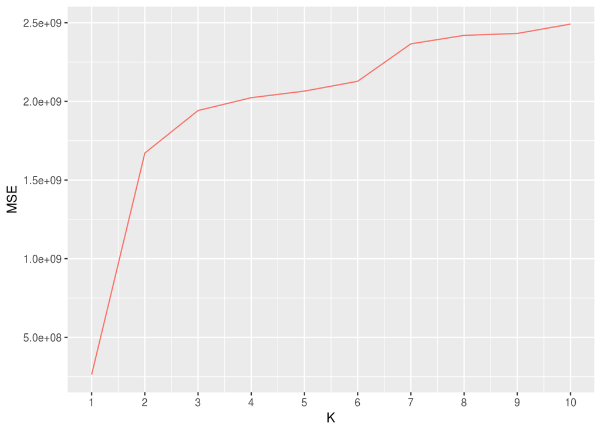

```r
results %>%
  ggplot(aes(x = K, y = MSE, color="red")) +
  geom_line() +
  scale_x_continuous(breaks = seq(1, 10, 1)) +
  theme(legend.position="none")
```